[figure not shown]

# Segmentation of contagion zones in New York State

```python
# Import required libraries
import pandas as pd
import numpy  as np
from bs4 import BeautifulSoup # this module helps in web scrapping.
import requests  # this module helps us to download a web page

# Matplotlib and associated plotting modules
from termcolor import colored as cl # text customization
import geopandas as gpd
import matplotlib.pyplot as plt
import matplotlib.cm as cm
import matplotlib.colors as colors

# Clustering
from sklearn.cluster import KMeans
```

## A- Phase 1 : Extract and Load all the datasets

Import the necessary variables that can speed up the spread of the virus

- Number of bus stops and metro stations (the more trips, the greater the risk of transmission)
- Number of cinemas (the more gatherings, the greater the risk of transmission)
- Number of schools (children are vectors of transmission)
- Number of hospitals
- number of shopping centers

Data will be obtained from :

- US Zip Code Latitude and Longitude
- Foursquare location data,
- Statistical data on the COVID19 situation in each city

```python
# Retreive the URL and creating a Beautiful soup object
url = "https://public.opendatasoft.com/explore/dataset/us-county-boundaries/download/?format=csv&disjunctive.statefp=true&disjunctive.countyfp=true&disjunctive.name=true&disjunctive.namelsad=true&disjunctive.stusab=true&disjunctive.state_name=true&refine.state_name=New+York&refine.statefp=36&timezone=Europe/Berlin&lang=fr&use_labels_for_header=true&csv_separator=%3B"

# Get the contents of the webpage in text format and store in a variable called data
data  = requests.get(url).text.split('\r\n')

# Create the dataframe with fout columns 'Longitude','Zip','Latitude' and 'Longitude'
NY_table = pd.DataFrame(columns=['State','County','Latitude','Longitude','geometry'])

for row in data[1: ]:
    if len(row)<6:
         pass
    else:
        State = row.split(';')[0]
        County = row.split(';')[6]
        Latitude = row.split(';')[18]
        Longitude = row.split(';')[19]
        geometry = row.split(';')[1]
        NY_table = NY_table.append({"State":'New York',"County":County.replace('New York','Manhattan'),  "Latitude":Latitude,"Longitude":Longitude, 'geometry': geometry}, ignore_index=True)

NY_table.head(10)
```

|  | State | County | Latitude | Longitude | geometry |
| --- | --- | --- | --- | --- | --- |
| 0 | New York | St. Lawrence | +44.4881125 | -075.0743110 | "{""type"": ""Polygon"", ""coordinates"": [[[-... |
| 1 | New York | Onondaga | +43.0065163 | -076.1961336 | "{""type"": ""Polygon"", ""coordinates"": [[[-... |
| 2 | New York | Monroe | +43.4644839 | -077.6646584 | "{""type"": ""Polygon"", ""coordinates"": [[[-... |
| 3 | New York | Schoharie | +42.5912940 | -074.4381718 | "{""type"": ""Polygon"", ""coordinates"": [[[-... |
| 4 | New York | Kings | +40.6350451 | -073.9506398 | "{""type"": ""Polygon"", ""coordinates"": [[[-... |
| 5 | New York | Nassau | +40.7296118 | -073.5894144 | "{""type"": ""Polygon"", ""coordinates"": [[[-... |
| 6 | New York | Rensselaer | +42.7104206 | -073.5138454 | "{""type"": ""Polygon"", ""coordinates"": [[[-... |
| 7 | New York | Oswego | +43.4614431 | -076.2092618 | "{""type"": ""Polygon"", ""coordinates"": [[[-... |
| 8 | New York | Otsego | +42.6297762 | -075.0288410 | "{""type"": ""Polygon"", ""coordinates"": [[[-... |
| 9 | New York | Clinton | +44.7527120 | -073.7056429 | "{""type"": ""Polygon"", ""coordinates"": [[[-... |

```python
NY_table.shape
```

```
(62, 5)
```

#### Define Foursquare Credentials and Version

```python
CLIENT_ID = '------' #  Foursquare ID
CLIENT_SECRET = '------' #  Foursquare Secret
VERSION = '20180605' # Foursquare API version

print('Your credentails:')
print('CLIENT_ID: ' + CLIENT_ID)
print('CLIENT_SECRET:' + CLIENT_SECRET)
```

```
Your credentails:
CLIENT_ID: ------
CLIENT_SECRET:------
```

```python
# Define function to get geo location of address :
def geo_location(address):
    # get geo location of address
    geolocator = Nominatim(user_agent="ny_explorer")
    location = geolocator.geocode(address)
    latitude = location.latitude
    longitude = location.longitude
    return latitude,longitude


# Define a function for getting the venues :
def get_venues(lat,lng):
    #set variables
    radius=1000
    LIMIT=100

    #url to fetch data from foursquare api
    url = 'https://api.foursquare.com/v2/venues/explore?&client_id={}&client_secret={}&v={}&ll={},{}&radius={}&limit={}'.format(
            CLIENT_ID,
            CLIENT_SECRET,
            VERSION,
            lat,
            lng,
            radius,
            LIMIT)

    # get all the data
    results = requests.get(url).json()
    venue_data=results["response"]['groups'][0]['items']
    venue_details=[]
    for row in venue_data:
        try:
            venue_id=row['venue']['id']
            venue_name=row['venue']['name']
            venue_category=row['venue']['categories'][0]['name']
            venue_details.append([venue_id,venue_name,venue_category])
        except KeyError:
            pass

    column_names=['ID','Name','Category']
    df = pd.DataFrame(venue_details,columns=column_names)
    return df



# Define function to retieve ratings and likes of the venue
def get_venue_details(lat,lng):
    #set variables
    radius=1000
    LIMIT=100

    #url to fetch data from foursquare api
    url = 'https://api.foursquare.com/v2/venues/explore?&client_id={}&client_secret={}&v={}&ll={},{}&radius={}&limit={}'.format(
            CLIENT_ID,
            CLIENT_SECRET,
            VERSION,
            lat,
            lng,
            radius,
            LIMIT)

    # get all the data
    results = requests.get(url).json()
    venue_data=results['response']['venue']
    venue_details=[]
    try:
        venue_id=venue_data['id']
        venue_name=venue_data['name']
        venue_category=row['venue']['categories'][0]['name']
        venue_likes=venue_data['likes']['count']
        venue_rating=venue_data['rating']
        venue_tips=venue_data['tips']['count']
        venue_details.append([venue_id,venue_name,venue_category,venue_likes,venue_rating,venue_tips])
    except KeyError:
        pass

    column_names=['ID','Name','Categories','Likes','Rating','Tips']
    df = pd.DataFrame(venue_details,columns=column_names)
    return df


# Function to groupe and aggregate all metrics by city
def compute_metrics(data):
    grouped_metrics = data.groupby('City').agg(
            Likes_metrics=('Likes', 'mean'),   # Get max of the duration column for each group
            Rating_metrics=('Rating', 'mean'), # Get min of the duration column for each group
            Tips_metrics=('Tips', 'mean')      # Get sum of the duration column for each group
        )
    return grouped_metrics


# Function to extract the list of neighborhood
def get_rest_detail_dataframe(geo_frame,type_resto):
    column_names=['State', 'City', 'ID','County','Categories','Likes','Rating','Tips']
    list_venus_data=pd.DataFrame(columns=column_names)
    for row in geo_frame.values.tolist():
        State, City, Zip, Latitude, Longitude = row
        venues = get_venue_details(Latitude,Longitude)
        list_venus=venues[venues['Category']== type_venus]
        for venus_detail in list_venus.values.tolist():
            id, name, categories, likes, rating, tips = venus_detail
            list_venus = list_venus.append({'State': State,
                                            'City': City,
                                            'ID': id,
                                            'County' : name,
                                            'Categories' : categories,
                                            'Likes': likes,
                                            'Rating': rating,
                                            'Tips': tips,
                                           }, ignore_index=True)

    return compute_metrics(list_venus)


# Function to merge all the metric dataset
def get_merge(NY_table):
    # Now we got all restaurants in NY City
    list_resto_NY = get_rest_detail_dataframe(NY_table,'Restaurant')
    # Now we got all schools in NY City
    list_school_NY = get_rest_detail_dataframe(NY_table,'Schools')
    # Now we got all bus stops in NY City
    list_bus_NY = get_rest_detail_dataframe(NY_table,'Bus Stops')
    # Now we got all metro stations in NY City
    list_metro_NY = get_rest_detail_dataframe(NY_table,'Metro Stations')
    # Now we got all metro stations in NY City
    list_shop_NY = get_rest_detail_dataframe(NY_table,'Shopping Centers')
    # Now we got all metro stations in NY City
    list_hospital_NY = get_rest_detail_dataframe(NY_table,'Hospital')
    all_list_metrics = [list_resto_NY, list_school_NY, list_bus_NY,list_shop_NY,list_hospital_NY]
    metric_merged = reduce(lambda  left,right: pd.merge(left,right,on=['DATE'], how='outer'), all_list_metrics)
    return metric_merged
```

As foursquare informations and metrics, we consider the following:

- **Tips** : Contains the total count of tips and groups with friends and others as groupTypes. Groups may change over time.
- **Like** : The count of users who have liked this venue, and groups containing any friends and others who have liked it. The groups included are subject to change.
- **Rating** : Numerical rating of the venue (0 through 10). Returned as part of an explore result, excluded in search results. Not all venues will have a rating.

```python
metric_merged =  get_merge(NY_table)
metric_merged.head(20)
```

[output not shown]

```python
metric_merged.shape
```

```
(62, 19)
```

### Statistical data on the COVID19 situation in each city : [Link to the dataset](https://news.google.com/covid19/map?hl=en-US&gl=US&ceid=US%3Aen&mid=%2Fm%2F059rby)

Imports updated statistical data on the COVID19 situation in each city:

- Number new contaminates (J-1),
- Number of deaths,
- Number of cases out of 1M.

```python
# Retreive the URL and creating a Beautiful soup object
url = "https://en.wikipedia.org/wiki/COVID-19_pandemic_in_New_York_(state)"

# Get the contents of the webpage in text format and store in a variable called data
data  = requests.get(url).text

# Create the dataframe with fout columns 'Longitude','Zip','Latitude' and 'Longitude'
Stat_table_sep = pd.DataFrame(columns=['County','Cases_sep','Deaths_sep','Recov_sep','Pop_sep','Cases_100k_sep','Deaths_100k_sep','Ratio_Deaths_Cases_sep'])
```

```python
# Create a BeautifulSoup object using the BeautifulSoup constructor
soup = BeautifulSoup(data, 'lxml')

# Find all html tables in the web page
table = soup.findAll('table',{'class':'wikitable plainrowheaders sortable'})

row_data_sep = [tr.text.strip().replace(',', '').replace('\n\n',';')  for tr in table[0].find_all('tr')]

for row in row_data_sep[2:64]:
    if len(row)<2:
         pass
    else:
        County = row.split(';')[0]
        Cases = row.split(';')[1]
        Deaths = row.split(';')[2]
        Recov = row.split(';')[3]
        Pop = row.split(';')[4]
        Cases_100k = row.split(';')[5]
        Deaths_100k = row.split(';')[6]
        Ratio_Deaths_Cases = row.split(';')[7]
        Stat_table_sep = Stat_table_sep.append({"County":County,
                                                "Cases_sep":float(Cases.replace(',','')),
                                                "Deaths_sep":float(Deaths.replace(',','')),
                                                "Recov_sep":float(Recov.replace('–','36').replace(',','')),
                                                "Pop_sep":float(Pop.replace(',','')),
                                                "Cases_100k_sep":float(Cases_100k.replace(',','')),
                                                "Deaths_100k_sep":float(Deaths_100k.replace(',','')),
                                                "Ratio_Deaths_Cases_sep":float(Ratio_Deaths_Cases.replace(',',''))}, ignore_index=True)


Stat_table_sep
```

|  | County | Cases_sep | Deaths_sep | Recov_sep | Pop_sep | Cases_100k_sep | Deaths_100k_sep | Ratio_Deaths_Cases_sep |
| --- | --- | --- | --- | --- | --- | --- | --- | --- |
| 0 | Albany | 1986.0 | 108.0 | 1457.0 | 305506.0 | 556.5 | 30.4 | 5.47 |
| 1 | Allegany | 58.0 | 2.0 | 41.0 | 46430.0 | 124.9 | 4.3 | 3.45 |
| 2 | Bronx | 46778.0 | 3295.0 | 36.0 | 1418207.0 | 3242.1 | 229.7 | 7.08 |
| 3 | Broome | 657.0 | 56.0 | 489.0 | 190488.0 | 236.8 | 20.5 | 8.65 |
| 4 | Cattaraugus | 145.0 | 4.0 | 100.0 | 76117.0 | 161.6 | 5.3 | 3.25 |
| ... | ... | ... | ... | ... | ... | ... | ... | ... |
| 57 | Washington | 250.0 | 14.0 | 212.0 | 61204.0 | 362.7 | 22.9 | 6.31 |
| 58 | Wayne | 137.0 | 2.0 | 74.0 | 89918.0 | 115.7 | 2.2 | 1.92 |
| 59 | Westchester | 34385.0 | 1407.0 | 21427.0 | 967506.0 | 3509.4 | 143.9 | 4.10 |
| 60 | Wyoming | 95.0 | 5.0 | 63.0 | 39859.0 | 238.3 | 12.5 | 5.26 |
| 61 | Yates | 54.0 | 7.0 | 45.0 | 24913.0 | 188.7 | 28.1 | 14.89 |

62 rows × 8 columns

Data is publicly reported by New York State Department of Health Updated on September 2, 2020:

- **Cases_sep** : The cumulative number of confirmed human cases reported to date. The actual number of infections is likely to be higher than reported.
- **Deaths_sep** : The cumulative number of confirmed human deaths reported to date. Reporting criteria vary between locations.
- **Recov_sep** : The cumulative Total of Recovered. May not correspond to actual current figures and not all recoveries may be reported.
- **Pop_sep** : The total population of the county reported to date.
- **Cases_100k_sep** : The Ratio of cumulative number of confirmed human cases reported per 100000 population.
- **Deaths_100k_sep** : The Ratio of cumulative number of confirmed human deaths reported per 100000 population.
- **Ratio_Deaths_Cases_sep** : The Ratio between cumulative number of cases and cumulative number of cases deaths.

```python
Stat_table_may = pd.DataFrame(columns=['County','Cases_may','Deaths_may','Cases_mil_may','Deaths_mil_may','Ratio_Deaths_case_may','Area_km2','Case_dens_km2_may','Pop_dens_km2_may'])

row_data_may = [tr.text.strip().replace('\n\n',';').replace(' County', '').replace(' (Brooklyn)', '') for tr in table[1].find_all('tr')]
for row in row_data_may[2:64]:
    if len(row)<2:
         pass
    else:
        County = row.split(';')[0]
        Cases_may = row.split(';')[1]
        Deaths_may = row.split(';')[2]
        Cases_mil_may = row.split(';')[3]
        Deaths_mil_may = row.split(';')[4]
        Ratio_Deaths_case_may = row.split(';')[5]
        Area_km2 = row.split(';')[13]
        Case_dens_km2_may = row.split(';')[11]
        Pop_dens_km2_may = row.split(';')[12]
        Stat_table_may = Stat_table_may.append({'County': County.replace('New York (Manhattan)','Manhattan'),
                                                'Cases_may': float(Cases_may.replace(',','')),
                                                'Deaths_may': float(Deaths_may.replace(',','')),
                                                'Cases_mil_may': float(Cases_mil_may.replace(',','')),
                                                'Deaths_mil_may': float(Deaths_mil_may.replace(',','')),
                                                'Ratio_Deaths_case_may': float(Ratio_Deaths_case_may.replace(',','')),
                                                'Area_km2': float(Area_km2.replace(',','')),
                                                'Case_dens_km2_may': float(Case_dens_km2_may.replace(',','')),
                                                'Pop_dens_km2_may': float(Pop_dens_km2_may.replace(',',''))}, ignore_index=True)

Stat_table_may
```

|  | County | Cases_may | Deaths_may | Cases_mil_may | Deaths_mil_may | Ratio_Deaths_case_may | Area_km2 | Case_dens_km2_may | Pop_dens_km2_may |
| --- | --- | --- | --- | --- | --- | --- | --- | --- | --- |
| 0 | Albany | 22440.0 | 366.0 | 5937.69 | 324.1 | 5.46 | 1380.0 | 0.91 | 221.0 |
| 1 | Allegany | 2956.0 | 81.0 | 759.40 | 43.4 | 5.71 | 2678.0 | 0.01 | 17.0 |
| 2 | Bronx | 161925.0 | 6272.0 | 31712.00 | 2264.0 | 7.14 | 149.0 | 261.18 | 9518.0 |
| 3 | Broome | 16070.0 | 330.0 | 1721.90 | 115.5 | 6.71 | 1852.0 | 0.18 | 103.0 |
| 4 | Cattaraugus | 4441.0 | 92.0 | 696.30 | 26.3 | 3.77 | 3393.0 | 0.02 | 22.0 |
| ... | ... | ... | ... | ... | ... | ... | ... | ... | ... |
| 57 | Washington | 1953.0 | 36.0 | 3039.00 | 81.7 | 2.69 | 2191.0 | 0.08 | 28.0 |
| 58 | Wayne | 3979.0 | 40.0 | 834.10 | 11.1 | 1.33 | 3585.0 | 0.02 | 25.0 |
| 59 | Westchester | 113204.0 | 2324.0 | 34411.00 | 1404.6 | 4.10 | 1295.0 | 22.88 | 747.0 |
| 60 | Wyoming | 2539.0 | 48.0 | 1731.10 | 125.4 | 7.25 | 1544.0 | 0.04 | 26.0 |
| 61 | Yates | 1091.0 | 25.0 | 722.50 | 40.1 | 5.56 | 974.0 | 0.02 | 26.0 |

62 rows × 9 columns

## B - Phase 2 : Data preparation and future engineering

```python
def normalize(df,feature):
    result = df.copy()
    for feature_name in feature:
        max_value = df[feature_name].max()
        min_value = df[feature_name].min()
        mean_value = df[feature_name].mean()
        result[feature_name] = (df[feature_name].replace('-',df[feature_name].mean()) - min_value) / (max_value - min_value)
    return result
```

```python
Firstmerge = pd.merge(NY_table,metric_merged,on='County',how='left')
Secondmerge = pd.merge(Firstmerge,Stat_table_sep,on='County',how='left')
Lastmerge =  pd.merge(Secondmerge,Stat_table_may,on='County',how='left')
feature_used = ['Cases_may','Deaths_may','Ratio_Deaths_case_may','Area_km2','Cases_sep','Deaths_sep','Recov_sep','Pop_sep','Ratio_Deaths_Cases_sep']


Lastmerge= normalize(Lastmerge,feature_used)
Lastmerge.shape
```

```
(62, 38)
```

```python
Lastmerge.head()
```

|  | State | County | Latitude | Longitude | geometry | Likes_Resto | Likes_Schools | Likes_Bus | Likes_Metro | Likes_Shopping | ... | Deaths_100k_sep | Ratio_Deaths_Cases_sep | Cases_may | Deaths_may | Cases_mil_may | Deaths_mil_may | Ratio_Deaths_case_may | Area_km2 | Case_dens_km2_may | Pop_dens_km2_may |
| --- | --- | --- | --- | --- | --- | --- | --- | --- | --- | --- | --- | --- | --- | --- | --- | --- | --- | --- | --- | --- | --- |
| 0 | New York | St. Lawrence | +44.4881125 | -075.0743110 | "{""type"": ""Polygon"", ""coordinates"": [[[-... | 63 | 97 | 24 | 87 | 50 | ... | 5.9 | 0.037077 | 0.022976 | 0.007998 | 5203.4 | 58.8 | 0.025428 | 1.000000 | 0.02 | 5.000 |
| 1 | New York | Onondaga | +43.0065163 | -076.1961336 | "{""type"": ""Polygon"", ""coordinates"": [[[-... | 42 | 19 | 49 | 85 | 35 | ... | 20.2 | 0.188985 | 0.133111 | 0.070345 | 2273.5 | 78.2 | 0.077408 | 0.279965 | 0.50 | 221.000 |
| 2 | New York | Monroe | +43.4644839 | -077.6646584 | "{""type"": ""Polygon"", ""coordinates"": [[[-... | 78 | 53 | 86 | 83 | 38 | ... | 32.8 | 0.237941 | 0.248051 | 0.125513 | 2111.2 | 157.7 | 0.168092 | 0.480051 | 0.44 | 210.000 |
| 3 | New York | Schoharie | +42.5912940 | -074.4381718 | "{""type"": ""Polygon"", ""coordinates"": [[[-... | 79 | 9 | 59 | 15 | 19 | ... | 1.3 | 0.131030 | 0.002703 | 0.000410 | 289.8 | 6.4 | 0.049955 | 0.215523 | 0.03 | 96.000 |
| 4 | New York | Kings | +40.6350451 | -073.9506398 | "{""type"": ""Polygon"", ""coordinates"": [[[-... | 17 | 97 | 83 | 55 | 14 | ... | 192.5 | 0.310655 | 1.000000 | 1.000000 | 21659.4 | 1664.9 | 0.204770 | 0.026476 | 186.61 | 10.199 |

5 rows × 38 columns

```python
# Extract the data we're interested in
lat = Lastmerge['Latitude'].values
lon = Lastmerge['Longitude'].values
population = Lastmerge['Pop_dens_km2_may'].values
area = Lastmerge['Cases_mil_may'].values

# 1. Draw the map background
fig = plt.figure(figsize=(8, 8))
m = Basemap(projection='lcc', resolution='h', lat_0=37.5, lon_0=-119,width=1E6, height=1.2E6)
m.shadedrelief()
m.drawcoastlines(color='gray')
m.drawcountries(color='gray')
m.drawstates(color='gray')

# 2. scatter city data, with color reflecting population
# and size reflecting area
m.scatter(lon, lat, latlon=True,c=np.log10(population), s=area,cmap='Reds', alpha=0.5)

# 3. create colorbar and legend
plt.colorbar(label=r'$\log_{10}({\rm population})$')
plt.clim(3, 7)

# make legend with dummy points
for a in [100, 300, 500]:
    plt.scatter([], [], c='k', alpha=0.5, s=a,label=str(a) + ' km$^2$')
plt.legend(scatterpoints=1, frameon=False,labelspacing=1, loc='lower left');
```

[figure not shown]

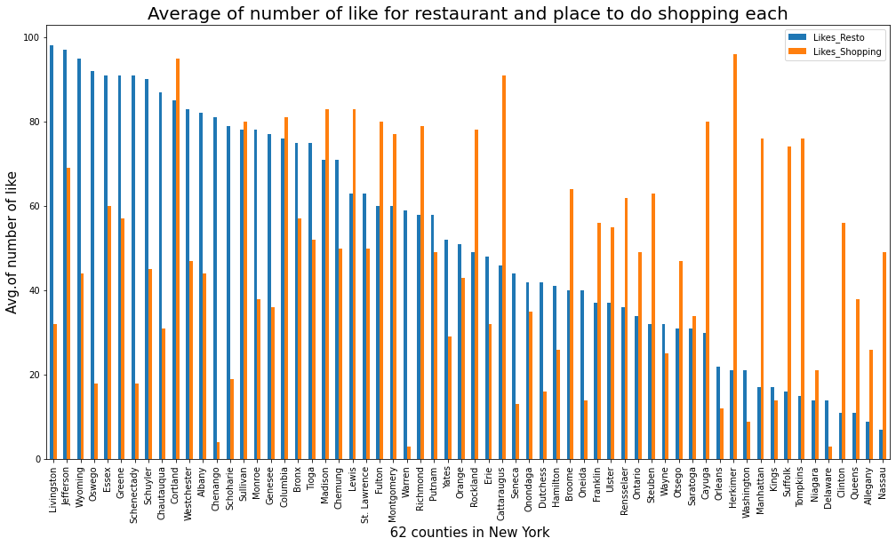

```python
Lastmerge_sorted_1= Lastmerge.sort_values(["Likes_Resto", "Likes_Shopping"],ascending=False)
Lastmerge_sorted_1.plot(x="County", y=["Likes_Resto", "Likes_Shopping"], kind="bar",figsize=(17,9))
plt.title('Average of number of like for restaurant and place to do shopping each', fontsize = 20)
plt.xlabel(' 62 counties in New York', fontsize = 15)
plt.ylabel('Avg.of number of like', fontsize=15)
plt.show()
```

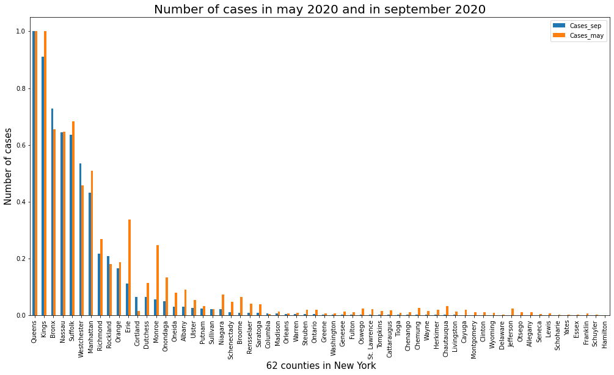

```python
Lastmerge_sorted_2= Lastmerge.sort_values(["Cases_sep", "Cases_may"],ascending=False)
Lastmerge_sorted_2.plot(x="County", y=["Cases_sep", "Cases_may"], kind="bar",figsize=(17,9))
plt.title('Number of cases in may 2020 and in september 2020', fontsize = 20)
plt.xlabel(' 62 counties in New York', fontsize = 15)
plt.ylabel('Number of cases', fontsize=15)
plt.show()
```

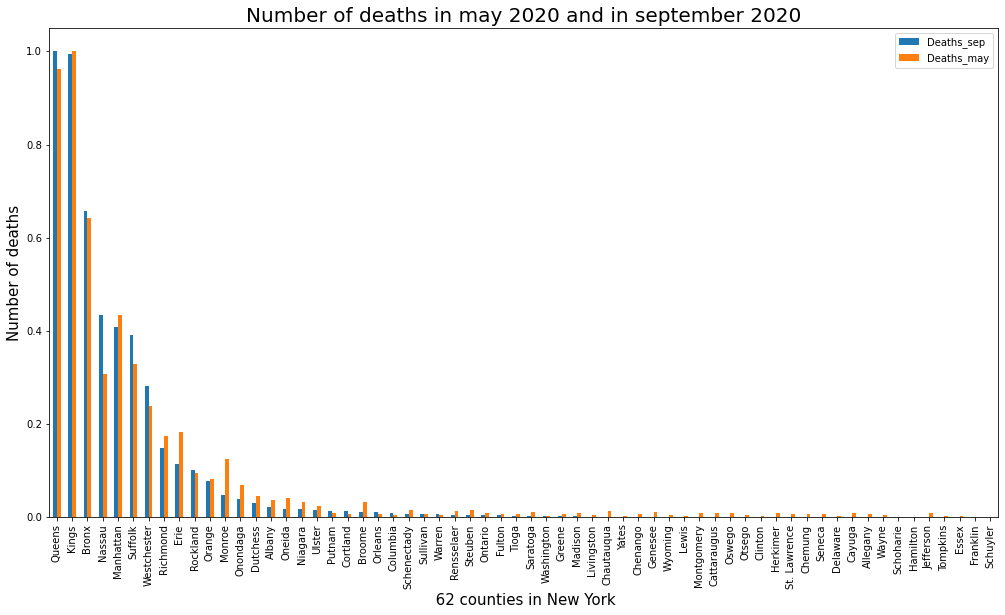

```python
Lastmerge_sorted_2= Lastmerge.sort_values(["Deaths_sep", "Deaths_may"],ascending=False)
Lastmerge_sorted_2.plot(x="County", y=["Deaths_sep", "Deaths_may"], kind="bar",figsize=(17,9))
plt.title('Number of deaths in may 2020 and in september 2020', fontsize = 20)
plt.xlabel(' 62 counties in New York', fontsize = 15)
plt.ylabel('Number of deaths', fontsize=15)
plt.show()
```

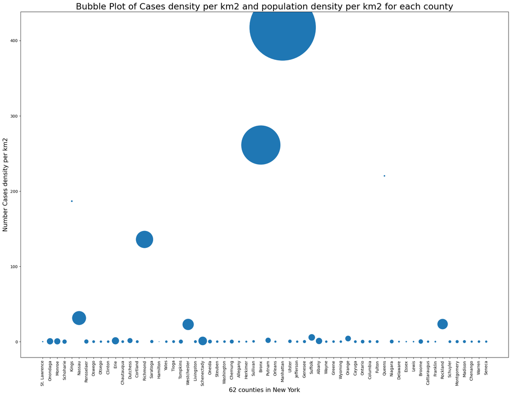

```python
plt.figure(figsize=(22,16), dpi = 100)
plt.scatter('County', 'Case_dens_km2_may', s='Pop_dens_km2_may',alpha=1, data=Lastmerge)
plt.xlabel('62 counties in New York', fontsize = 15)
plt.xticks(Lastmerge['County'], rotation='vertical')
plt.ylabel('Number Cases density per km2', fontsize=15)
plt.title("Bubble Plot of Cases density per km2 and population density per km2 for each county", size=22)
```

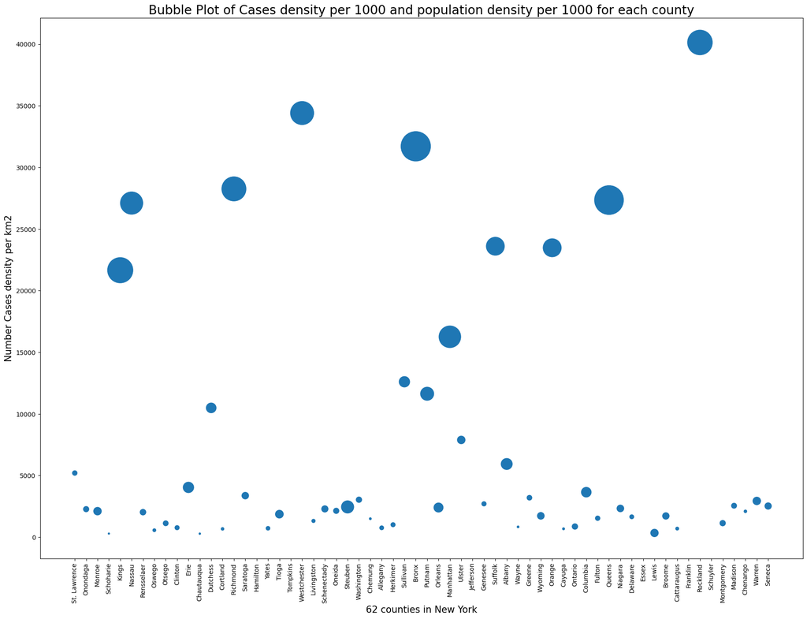

```python
plt.figure(figsize=(22,16), dpi = 100)
plt.scatter('County', 'Cases_mil_may', s='Deaths_mil_may',alpha=1, data=Lastmerge)
plt.xlabel('62 counties in New York', fontsize = 15)
plt.xticks(Lastmerge['County'], rotation='vertical')
plt.ylabel('Number Cases density per km2', fontsize=15)
plt.title("Bubble Plot of Cases density per 1000 and population density per 1000 for each county", size=20)
```

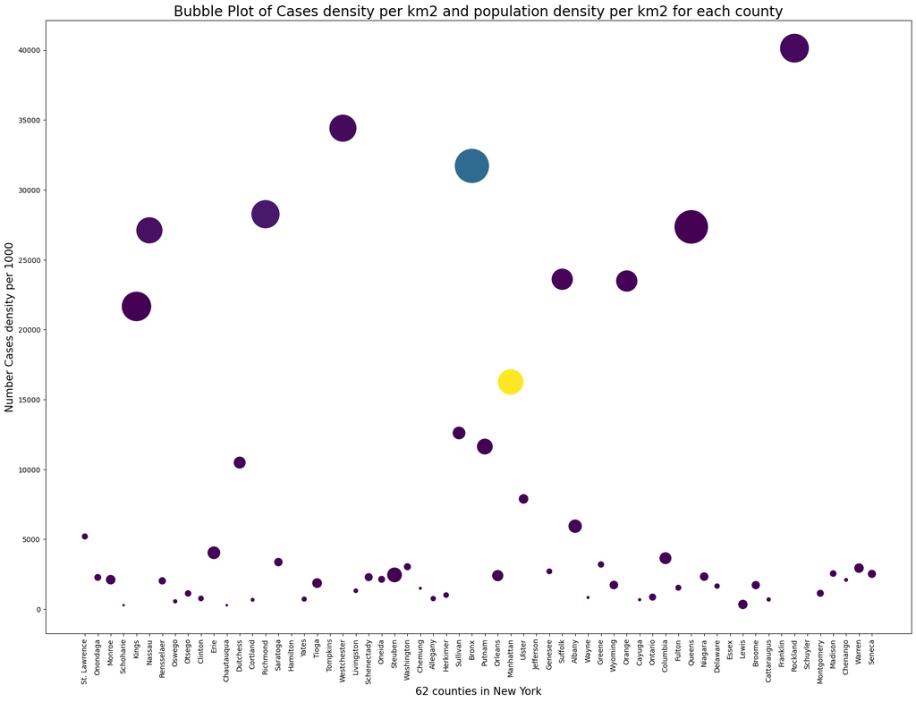

```python
plt.figure(figsize=(22,16), dpi = 100)
plt.scatter('County', 'Cases_mil_may', s='Deaths_mil_may',c='Pop_dens_km2_may',alpha=1, data=Lastmerge)
plt.xlabel('62 counties in New York', fontsize = 15)
plt.xticks(Lastmerge['County'], rotation='vertical')
plt.ylabel('Number Cases density per 1000', fontsize=15)
plt.title("Bubble Plot of Cases density per km2 and population density per km2 for each county", size=20)
```

## C - Phase 3: Segmentation and clustering

#### Modeling : Under these updated metrics, micro-cluster zones will now be determined using K-means.

We can build the K-Means in python using the KMeans algorithm provided by the scikit-learn package. The KMeans class has many parameters that can be used, but we will be using these three:

1. Init : Initialization method of the centroids. The value will be: ‘k-means++’. k-means++ - Selects initial cluster centers for the k-means clustering in a smart way to speed up convergence.
2. n_clusters : The number of clusters to form as well as the number of centroids to generate. The value will be 5
3. n_init : Number of times the k-means algorithm will be run with different centroid seeds

```python
feature_fit = ['Pop_dens_km2_may','Case_dens_km2_may','Deaths_mil_may','Cases_mil_may']
Lastmerge= normalize(Lastmerge,feature_fit)
Lastmerge.shape


X = Lastmerge.iloc[:, 5:]
X
```

|  | Likes_Resto | Likes_Schools | Likes_Bus | Likes_Metro | Likes_Shopping | Likes_Hospital | Rating_Resto | Rating_Schools | Rating_Bus | Rating_Metro | ... | Deaths_100k_sep | Ratio_Deaths_Cases_sep | Cases_may | Deaths_may | Cases_mil_may | Deaths_mil_may | Ratio_Deaths_case_may | Area_km2 | Case_dens_km2_may | Pop_dens_km2_may |
| --- | --- | --- | --- | --- | --- | --- | --- | --- | --- | --- | --- | --- | --- | --- | --- | --- | --- | --- | --- | --- | --- |
| 0 | 63 | 97 | 24 | 87 | 50 | 73 | 7.6 | 3.0 | 5.7 | 3.3 | ... | 5.9 | 0.037077 | 0.022976 | 0.007998 | 0.124010 | 0.025972 | 0.025428 | 1.000000 | 0.000048 | 0.000145 |
| 1 | 42 | 19 | 49 | 85 | 35 | 91 | 5.0 | 6.1 | 4.2 | 5.8 | ... | 20.2 | 0.188985 | 0.133111 | 0.070345 | 0.050539 | 0.034541 | 0.077408 | 0.279965 | 0.001198 | 0.007987 |
| 2 | 78 | 53 | 86 | 83 | 38 | 23 | 4.9 | 9.4 | 2.1 | 4.3 | ... | 32.8 | 0.237941 | 0.248051 | 0.125513 | 0.046469 | 0.069655 | 0.168092 | 0.480051 | 0.001054 | 0.007588 |
| 3 | 79 | 9 | 59 | 15 | 19 | 15 | 5.5 | 2.3 | 7.4 | 8.0 | ... | 1.3 | 0.131030 | 0.002703 | 0.000410 | 0.000795 | 0.002827 | 0.049955 | 0.215523 | 0.000072 | 0.003449 |
| 4 | 17 | 97 | 83 | 55 | 14 | 42 | 4.9 | 4.2 | 4.0 | 8.6 | ... | 192.5 | 0.310655 | 1.000000 | 1.000000 | 0.536665 | 0.735380 | 0.204770 | 0.026476 | 0.447088 | 0.000334 |
| ... | ... | ... | ... | ... | ... | ... | ... | ... | ... | ... | ... | ... | ... | ... | ... | ... | ... | ... | ... | ... | ... |
| 57 | 60 | 56 | 38 | 55 | 77 | 49 | 8.1 | 2.8 | 8.1 | 2.5 | ... | 8.1 | 0.186825 | 0.010571 | 0.009434 | 0.022057 | 0.035910 | 0.160666 | 0.138387 | 0.000120 | 0.001634 |
| 58 | 71 | 25 | 19 | 49 | 83 | 35 | 8.7 | 4.2 | 9.3 | 8.7 | ... | 9.9 | 0.085673 | 0.013310 | 0.008203 | 0.057507 | 0.031140 | 0.062106 | 0.228495 | 0.000264 | 0.001452 |
| 59 | 81 | 20 | 31 | 28 | 4 | 48 | 8.6 | 8.8 | 7.6 | 2.0 | ... | 6.4 | 0.091433 | 0.011244 | 0.007178 | 0.046115 | 0.009364 | 0.022727 | 0.313083 | 0.000096 | 0.000690 |
| 60 | 59 | 40 | 26 | 39 | 3 | 77 | 5.7 | 5.0 | 9.2 | 7.6 | ... | 42.2 | 0.403168 | 0.008518 | 0.005742 | 0.067255 | 0.069081 | 0.119712 | 0.302733 | 0.000192 | 0.000980 |
| 61 | 44 | 55 | 7 | 49 | 13 | 28 | 6.8 | 5.7 | 4.3 | 8.2 | ... | 11.2 | 0.138589 | 0.005348 | 0.006153 | 0.056898 | 0.049602 | 0.099910 | 0.108029 | 0.000120 | 0.000726 |

62 rows × 33 columns

```python
clusters = 5
model = KMeans(init = 'k-means++',n_clusters = clusters, n_init = 12)
model.fit(X)

labels = model.labels_ +1
print(cl(labels[:100], attrs = ['bold']))
```

```
[4 4 4 1 2 2 4 1 1 1 4 1 3 1 2 4 1 1 1 1 5 1 4 4 1 4 1 1 1 3 5 3 4 3 4 1 4
 2 4 1 4 1 2 1 1 4 4 2 4 1 1 1 1 1 1 5 1 1 4 1 4 1]
```

```python
def scalePercentage(df,feature):
    result = df.copy()
    for feature_name in feature:
        value = 300
        result[feature_name] = df[feature_name]*value
    return result
```

```python
feature_scale = ['Deaths_mil_may','Cases_mil_may']
feature_final = ['County','Deaths_mil_may','Cases_mil_may', 'Pop_dens_km2_may','Cluster_class']
Lastmerge['Cluster_class'] = labels
inter_dataframe = Lastmerge[feature_final]

final_dataframe = scalePercentage(inter_dataframe,feature_scale)
final_dataframe.head()
```

|  | County | Deaths_mil_may | Cases_mil_may | Pop_dens_km2_may | Cluster_class |
| --- | --- | --- | --- | --- | --- |
| 0 | St. Lawrence | 7.791519 | 37.202931 | 0.000145 | 4 |
| 1 | Onondaga | 10.362191 | 15.161625 | 0.007987 | 4 |
| 2 | Monroe | 20.896643 | 13.940661 | 0.007588 | 4 |
| 3 | Schoharie | 0.848057 | 0.238476 | 0.003449 | 1 |
| 4 | Kings | 220.613958 | 160.999551 | 0.000334 | 2 |

```python
final_dataframe.head(20)
```

|  | County | Deaths_mil_may | Cases_mil_may | Pop_dens_km2_may | Cluster_class |
| --- | --- | --- | --- | --- | --- |
| 0 | St. Lawrence | 7.791519 | 37.202931 | 0.000145 | 4 |
| 1 | Onondaga | 10.362191 | 15.161625 | 0.007987 | 4 |
| 2 | Monroe | 20.896643 | 13.940661 | 0.007588 | 4 |
| 3 | Schoharie | 0.848057 | 0.238476 | 0.003449 | 1 |
| 4 | Kings | 220.613958 | 160.999551 | 0.000334 | 2 |
| 5 | Nassau | 172.844523 | 201.969191 | 0.041969 | 2 |
| 6 | Rensselaer | 11.687279 | 13.320775 | 0.003304 | 4 |
| 7 | Oswego | 3.392226 | 2.297490 | 0.001198 | 1 |
| 8 | Otsego | 8.904594 | 6.530618 | 0.000799 | 1 |
| 9 | Clinton | 6.585689 | 3.853222 | 0.000980 | 1 |
| 10 | Erie | 38.652827 | 28.438016 | 0.010456 | 4 |
| 11 | Chautauqua | 1.046820 | 0.192586 | 0.001162 | 1 |
| 12 | Dutchess | 33.776502 | 76.964395 | 0.004974 | 3 |
| 13 | Cortland | 2.782686 | 3.117484 | 0.001307 | 1 |
| 14 | Richmond | 201.492933 | 210.642477 | 0.065205 | 2 |
| 15 | Saratoga | 15.993816 | 23.404452 | 0.001743 | 4 |
| 16 | Hamilton | 0.000000 | 3.168640 | 0.000000 | 1 |
| 17 | Yates | 5.313604 | 3.493628 | 0.000908 | 1 |
| 18 | Tioga | 21.996466 | 12.104324 | 0.001271 | 1 |
| 19 | Tompkins | 0.000000 | 7.555987 | 0.002977 | 1 |

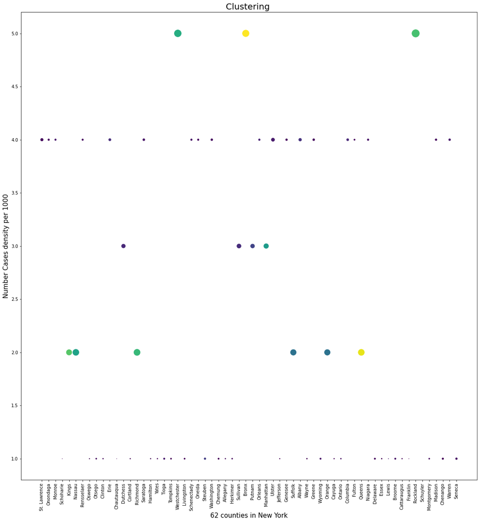

```python
plt.figure(figsize=(19,20))
plt.scatter('County', 'Cluster_class', s='Cases_mil_may',c='Deaths_mil_may',alpha=5, data=final_dataframe)
plt.xlabel('62 counties in New York', fontsize = 15)
plt.xticks(final_dataframe['County'], rotation='vertical')
plt.ylabel('Number Cases density per 1000', fontsize=15)
plt.title("Clustering ", size=20)
```

Let’s look at the distribution of cluster based on their Cases and Deaths using a bubble plot and the color represents the cluster value.

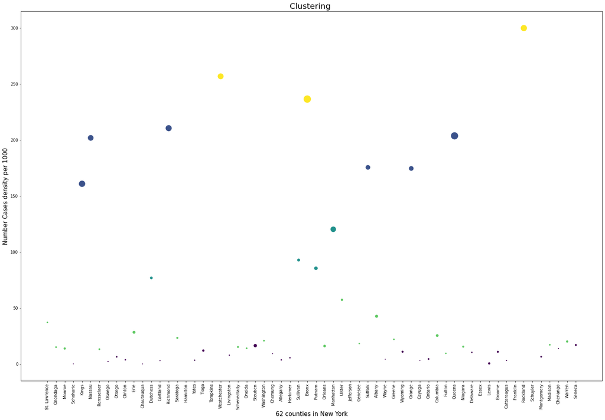

```python
plt.figure(figsize=(26,17))
plt.scatter('County', 'Cases_mil_may', s='Deaths_mil_may',c='Cluster_class',alpha=5, data=final_dataframe)
plt.xlabel('62 counties in New York', fontsize = 15)
plt.xticks(final_dataframe['County'], rotation='vertical')
plt.ylabel('Number Cases density per 1000', fontsize=15)
plt.title("Clustering ", size=20)
```

We hope that this study will inspire new reflections on the COVID-19 pandemic by readers.